# Final

## H2O and Sklearn

- Apply in-memory distributed computational tool *H2O*
- Learn Shap and its visualizations

## Import libraries and define auxiliary functions

```python
# basic
import pandas as pd
import numpy as np

# H2o
import h2o
from h2o.grid.grid_search import H2OGridSearch
from h2o.estimators import H2ORandomForestEstimator

# sklearn
from sklearn.ensemble import RandomForestClassifier

# plot
import matplotlib.pyplot as plt
import pylab as pl
import seaborn as sns

# processing
from sklearn.preprocessing import StandardScaler

# model evaluation
import shap
from sklearn.metrics import classification_report
from sklearn.metrics import roc_curve,auc
from sklearn.metrics import average_precision_score
from sklearn.metrics import precision_recall_curve
from sklearn import metrics

# warning
import warnings; warnings.filterwarnings("ignore")
```

```python
pd.__version__
```

```
'1.4.4'
```

### Pre-defined Functions

```python
# define H2o dataframe
def H2odf(x_train, x_test, y_train, y_test):
    x_train1 = x_train.copy()
    x_train1['loan_default'] = y_train
    x_train1 = h2o.H2OFrame(x_train1)
    train, valid = x_train1.split_frame(ratios=[.8], seed=0)
    # test
    x_test1 = x_test.copy()
    x_test1['loan_default'] = y_test
    test = h2o.H2OFrame(x_test1)
    return train, valid, test
```

```python
def global_shap_importance(model, X):
    """ Return a dataframe containing the features sorted by Shap importance
    Parameters
    ----------
    model : The tree-based model
    X : pd.Dataframe
         training set/test set/the whole dataset ... (without the label)
    Returns
    -------
    pd.Dataframe
        A dataframe containing the features sorted by Shap importance
    """
    explainer = shap.Explainer(model)
    shap_values = explainer(X)
    cohorts = {"": shap_values}
    cohort_labels = list(cohorts.keys())
    cohort_exps = list(cohorts.values())
    for i in range(len(cohort_exps)):
        if len(cohort_exps[i].shape) == 2:
            cohort_exps[i] = cohort_exps[i].abs.mean(0)
    features = cohort_exps[0].data
    feature_names = cohort_exps[0].feature_names
    values = np.array([cohort_exps[i].values for i in range(len(cohort_exps))])
    feature_importance = pd.DataFrame(
        list(zip(feature_names, sum(values))), columns=['features', 'importance'])
    feature_importance.sort_values(
        by=['importance'], ascending=False, inplace=True)
    return feature_importance
```

```python
def VarImp(model_name, n, color):
    # plot the variable importance
    variables = model_name._model_json['output']['variable_importances']['variable'][0:n]
    scaled_importance = model_name._model_json['output']['variable_importances']['scaled_importance'][0:n]
    ax = sns.barplot(x=scaled_importance, y=variables, palette = color)
    ax.set_xlabel('Scaled Importance')
    ax.set_title(f'Top {n} Variable Importance')
    plt.show()
```

```python
def createGains(model):
    predictions = model.predict(test)
    test_scores = test['loan_default'].cbind(predictions).as_data_frame()

    #sort on prediction (descending), add id, and decile for groups containing 1/10 of datapoints
    test_scores = test_scores.sort_values(by='predict',ascending=False)
    test_scores['row_id'] = range(0,0+len(test_scores))
    test_scores['decile'] = ( test_scores['row_id'] / (len(test_scores)/10) ).astype(int)
    #see count by decile
    test_scores.loc[test_scores['decile'] == 10]=9
    test_scores['decile'].value_counts()

    #create gains table
    gains = test_scores.groupby('decile')['loan_default'].agg(['count','sum'])
    gains.columns = ['count','actual']
    gains

    #add features to gains table
    gains['non_actual'] = gains['count'] - gains['actual']
    gains['cum_count'] = gains['count'].cumsum()
    gains['cum_actual'] = gains['actual'].cumsum()
    gains['cum_non_actual'] = gains['non_actual'].cumsum()
    gains['percent_cum_actual'] = (gains['cum_actual'] / np.max(gains['cum_actual'])).round(2)
    gains['percent_cum_non_actual'] = (gains['cum_non_actual'] / np.max(gains['cum_non_actual'])).round(2)
    gains['if_random'] = np.max(gains['cum_actual']) /10
    gains['if_random'] = gains['if_random'].cumsum()
    gains['lift'] = (gains['cum_actual'] / gains['if_random']).round(2)
    gains['K_S'] = np.abs( gains['percent_cum_actual'] -  gains['percent_cum_non_actual'] ) * 100
    gains['gain']=(gains['cum_actual']/gains['cum_count']*100).round(2)
    gains = pd.DataFrame(gains)
    return(gains)
```

```python
def createGains1(model, test, y_actual):
    predictions = model.predict(test)
    y_actual['predict'] = predictions
    test_scores = y_actual

    #sort on prediction (descending), add id, and decile for groups containing 1/10 of datapoints
    test_scores = test_scores.sort_values(by='predict',ascending=False)
    test_scores['row_id'] = range(0,0+len(test_scores))
    test_scores['decile'] = ( test_scores['row_id'] / (len(test_scores)/10) ).astype(int)
    #see count by decile
    test_scores.loc[test_scores['decile'] == 10]=9
    test_scores['decile'].value_counts()

    #create gains table
    gains = test_scores.groupby('decile')['loan_default'].agg(['count','sum'])
    gains.columns = ['count','actual']
    gains

    #add features to gains table
    gains['non_actual'] = gains['count'] - gains['actual']
    gains['cum_count'] = gains['count'].cumsum()
    gains['cum_actual'] = gains['actual'].cumsum()
    gains['cum_non_actual'] = gains['non_actual'].cumsum()
    gains['percent_cum_actual'] = (gains['cum_actual'] / np.max(gains['cum_actual'])).round(2)
    gains['percent_cum_non_actual'] = (gains['cum_non_actual'] / np.max(gains['cum_non_actual'])).round(2)
    gains['if_random'] = np.max(gains['cum_actual']) /10
    gains['if_random'] = gains['if_random'].cumsum()
    gains['lift'] = (gains['cum_actual'] / gains['if_random']).round(2)
    gains['K_S'] = np.abs( gains['percent_cum_actual'] -  gains['percent_cum_non_actual'] ) * 100
    gains['gain']=(gains['cum_actual']/gains['cum_count']*100).round(2)
    gains = pd.DataFrame(gains)
    return(gains)
```

```python
def ROC_AUC1(my_result,df,target):
    # ROC
    y_actual = df[target].as_data_frame()
    y_pred = my_result.predict(df).as_data_frame()['p1']
    fpr = list()
    tpr = list()
    roc_auc = list()
    fpr,tpr,_ = roc_curve(y_actual,y_pred)
    roc_auc = auc(fpr,tpr)

    # Precision-Recall
    average_precision = average_precision_score(y_actual,y_pred)

    print('')
    print('   * ROC curve: The ROC curve plots the true positive rate vs. the false rositive sate')
    print('')
    print('	  * The area under the curve (AUC): A value between 0.5 (random) and 1.0 (perfect), measuring the prediction accuracy')
    print('')
    print('   * Recall (R) = The number of true positives / (the number of true positives + the number of false negatives)')
    print('')

    # plotting
    plt.figure(figsize=(14,6))

    # ROC
    plt.subplot(1,2,1)
    plt.plot(fpr,tpr,color='darkorange',lw=2,label='ROC curve (aare=%0.2f)' % roc_auc)
    plt.plot([0,1],[0,1],color='navy',lw=3,linestyle='--')
    plt.xlim([0.0,1.0])
    plt.ylim([0.0,1.05])
    plt.xlabel('False Positive Rate')
    plt.ylabel('True Positive Rate')
    plt.title('Receiver operating characteristic: AUC={0:0.4f}'.format(roc_auc))
    plt.legend(loc='lower right')

    # Precision-Recall
    plt.subplot(1,2,2)
    precision,recall,_ = precision_recall_curve(y_actual,y_pred)
    plt.step(recall,precision,color='b',alpha=0.2,where='post')
    plt.fill_between(recall,precision,step='post',alpha=0.2,color='b')
    plt.xlabel('Recall')
    plt.ylabel('Precision')
    plt.ylim([0.0,1.05])
    plt.xlim([0.0,1.0])
    plt.title('Precision-Recall curve: PR={0:0.4f}'.format(average_precision))
    plt.show()
```

```python
def ROC_AUC2(y_actual, y_pred):
    # ROC
    y_pred = pd.DataFrame(y_pred_prob)[1]
    fpr = list()
    tpr = list()
    roc_auc = list()
    fpr,tpr,_ = roc_curve(y_actual,y_pred)
    roc_auc = auc(fpr,tpr)

    # Precision-Recall
    average_precision = average_precision_score(y_actual,y_pred)

    print('')
    print('   * ROC curve: The ROC curve plots the true positive rate vs. the false rositive sate')
    print('')
    print('	  * The area under the curve (AUC): A value between 0.5 (random) and 1.0 (perfect), measuring the prediction accuracy')
    print('')
    print('   * Recall (R) = The number of true positives / (the number of true positives + the number of false negatives)')
    print('')

    # plotting
    plt.figure(figsize=(14,6))

    # ROC
    plt.subplot(1,2,1)
    plt.plot(fpr,tpr,color='darkorange',lw=2,label='ROC curve (aare=%0.2f)' % roc_auc)
    plt.plot([0,1],[0,1],color='navy',lw=3,linestyle='--')
    plt.xlim([0.0,1.0])
    plt.ylim([0.0,1.05])
    plt.xlabel('False Positive Rate')
    plt.ylabel('True Positive Rate')
    plt.title('Receiver operating characteristic: AUC={0:0.4f}'.format(roc_auc))
    plt.legend(loc='lower right')

    # Precision-Recall
    plt.subplot(1,2,2)
    precision,recall,_ = precision_recall_curve(y_actual,y_pred)
    plt.step(recall,precision,color='b',alpha=0.2,where='post')
    plt.fill_between(recall,precision,step='post',alpha=0.2,color='b')
    plt.xlabel('Recall')
    plt.ylabel('Precision')
    plt.ylim([0.0,1.05])
    plt.xlim([0.0,1.0])
    plt.title('Precision-Recall curve: PR={0:0.4f}'.format(average_precision))
    plt.show()
```

```python
def Fimp():
    importances = clf.feature_importances_
    # Sort the feature importance in descending order
    sorted_indices = np.argsort(importances)[::-1]
    feat_labels = strong_predictors

    plt.title('Feature Importance')
    plt.bar(range(x_train[strong_predictors].shape[1]), importances[sorted_indices], align='center')
    plt.xticks(range(x_train[strong_predictors].shape[1]), x_train[strong_predictors].columns[sorted_indices], rotation=90)
    plt.tight_layout()
    plt.show()
```

## Read & Inspect Data

**Data Processing Detail:**

1. Imputed missing & meaningless values
2. Created bins for columns with missing values
3. Caulcated Weight of Evidence and Information Value for some features
4. Broke AP005 into: Month, Day, Hours, Daytime/Nighttime
5. Target encoding for categorical variables

```python
# read prepared data
x_train = pd.read_csv('X_train_processed.csv')
x_test = pd.read_csv('X_test_processed.csv')
y_train = pd.read_csv('y_train.csv')
y_test = pd.read_csv('y_test.csv')
```

```python
# drop id since it is not that meaningful
x_train = x_train.drop('id', 1)
x_test = x_test.drop('id', 1)
```

```python
x_train.shape
```

```
(64000, 162)
```

```python
pd.set_option('display.max_columns', None)
x_test.tail(3)
```

|  | CD107_bin | TD029_bin | CD167_bin | TD022_bin | CD072_bin | PA023_bin | CD160_bin | CD117_bin | CD135_bin | CD123_bin | PA031_bin | CD115_bin | CD164_bin | CD113_bin | TD027_bin | CD173_bin | TD028_bin | CD170_bin | TD026_bin | TD024_bin | CD106_bin | CD008_bin | CD018_bin | CD088_bin | CD152_bin | PA028_bin | CD162_bin | CD169_bin | CD121_bin | … |
| --- | --- | --- | --- | --- | --- | --- | --- | --- | --- | --- | --- | --- | --- | --- | --- | --- | --- | --- | --- | --- | --- | --- | --- | --- | --- | --- | --- | --- | --- | --- |
| 15997 | 0.231979 | 0.193625 | 0.200770 | 0.182566 | 0.198499 | 0.257321 | 0.228571 | 0.211870 | 0.183725 | 0.206796 | 0.250631 | 0.209649 | 0.218668 | 0.238722 | 0.195271 | 0.191531 | 0.19526 | 0.198378 | 0.19539 | 0.281250 | 0.238411 | 0.220166 | 0.186827 | 0.183011 | 0.186505 | 0.257808 | 0.198230 | 0.199257 | 0.203348 | … |
| 15998 | 0.168792 | 0.193625 | 0.177888 | 0.182566 | 0.180892 | 0.257321 | 0.218792 | 0.183755 | 0.177764 | 0.174479 | 0.217284 | 0.186256 | 0.221333 | 0.166667 | 0.195271 | 0.204675 | 0.19526 | 0.208900 | 0.19539 | 0.231584 | 0.164714 | 0.172792 | 0.170558 | 0.188548 | 0.187271 | 0.220938 | 0.218772 | 0.206940 | 0.181760 | … |
| 15999 | 0.204070 | 0.193625 | 0.181787 | 0.219178 | 0.179462 | 0.173585 | 0.172949 | 0.206337 | 0.200500 | 0.203943 | 0.173585 | 0.201613 | 0.177545 | 0.185185 | 0.195271 | 0.184566 | 0.19526 | 0.174185 | 0.19539 | 0.195633 | 0.179454 | 0.178571 | 0.193803 | 0.195977 | 0.188868 | 0.170253 | 0.173187 | 0.165948 | 0.203348 | … |

```python
x_train.info(verbose='all')
```

```
<class 'pandas.core.frame.DataFrame'>
RangeIndex: 64000 entries, 0 to 63999
Data columns (total 162 columns):
 #    Column         Dtype
---   ------         -----
 0    CD107_bin      float64
 1    TD029_bin      float64
 2    CD167_bin      float64
 3    TD022_bin      float64
 4    CD072_bin      float64
 5    PA023_bin      float64
 6    CD160_bin      float64
 7    CD117_bin      float64
 8    CD135_bin      float64
 9    CD123_bin      float64
```

[output cut: 154 more lines]

```python
# check the distribution of the target variable
y_train.value_counts()
```

```
loan_default
0               51610
1               12390
dtype: int64
```

```python
ratio = round(12390 / 51610 * 100, 2)
print(f'In the train dataset, loan default cases are about {ratio}% of all investigations')
```

[output not shown]

## H2O DRF

### Initialize H2O

H2O instance is called through terminal everytime

```python
# cd ~/Downloads/h2o-3.38.0.2
# java -jar h2o.jar
h2o.init()
```

```
Checking whether there is an H2O instance running at http://localhost:54321 . connected.
```

| H2O_cluster_uptime: | 2 hours 46 mins |
| --- | --- |
| H2O_cluster_timezone: | America/New_York |
| H2O_data_parsing_timezone: | UTC |
| H2O_cluster_version: | 3.38.0.2 |
| H2O_cluster_version_age: | 1 month and 6 days |
| H2O_cluster_name: | H2O_from_python_sayua_nrifls |
| H2O_cluster_total_nodes: | 1 |
| H2O_cluster_free_memory: | 2.322 Gb |
| H2O_cluster_total_cores: | 12 |
| H2O_cluster_allowed_cores: | 12 |
| H2O_cluster_status: | locked, healthy |
| H2O_connection_url: | http://localhost:54321 |
| H2O_connection_proxy: | {"http": null, "https": null} |
| H2O_internal_security: | False |
| Python_version: | 3.8.11 final |

### Create H2O Dataframe

```python
# convert df to H2O df
train, valid, test = H2odf(x_train, x_test, y_train, y_test)
# Set the predictors and response; set the factors:
train['loan_default'] = train['loan_default'].asfactor()
```

```
Parse progress: |████████████████████████████████████████████████████████████████| (done) 100%
Parse progress: |████████████████████████████████████████████████████████████████| (done) 100%
```

### Distributed Random Forest (DRF)

Use the best parameter set tested from a previous assignment

```python
# Build and train the model:
forest = H2ORandomForestEstimator(seed=0, ntrees=500, max_depth=12, balance_classes=True, nfolds=10)
```

```python
forest.train(x=list(x_train.columns), y='loan_default', training_frame=train, validation_frame=valid);
```

```
drf Model Build progress: |██████████████████████████████████████████████████████| (done) 100%
```

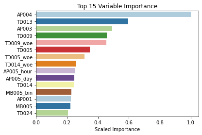

```python
VarImp(forest, 15, "Paired")
```

### H2O Explainer Pipeline

- Residual Analysis
- Variable Importance
- SHAP Summary
- Partial Dependence Plots
- Individual Conditional Expectation

Residual Analysis

> Residual Analysis plots the fitted values vs residuals on a test dataset. Ideally, residuals should be randomly distributed. Patterns in this plot can indicate potential problems with the model selection, e.g., using simpler model than necessary, not accounting for heteroscedasticity, autocorrelation, etc. Note that if you see "striped" lines of residuals, that is an artifact of having an integer valued (vs a real valued) response variable.

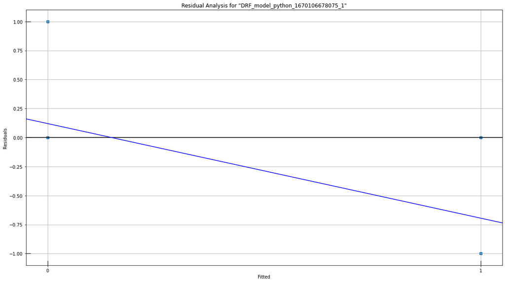

Variable Importance

> The variable importance plot shows the relative importance of the most important variables in the model.

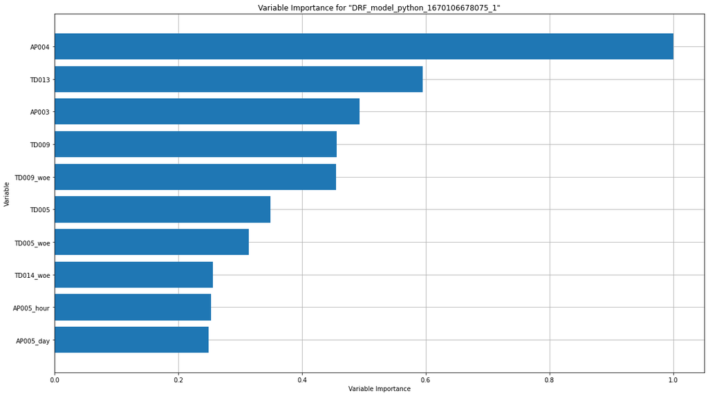

SHAP Summary

> SHAP summary plot shows the contribution of the features for each instance (row of data). The sum of the feature contributions and the bias term is equal to the raw prediction of the model, i.e., prediction before applying inverse link function.

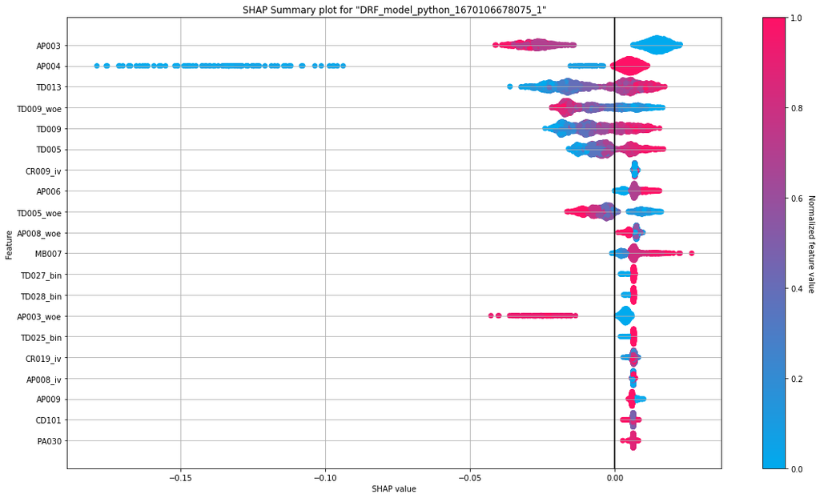

Partial Dependence Plots

> Partial dependence plot (PDP) gives a graphical depiction of the marginal effect of a variable on the response. The effect of a variable is measured in change in the mean response. PDP assumes independence between the feature for which is the PDP computed and the rest.

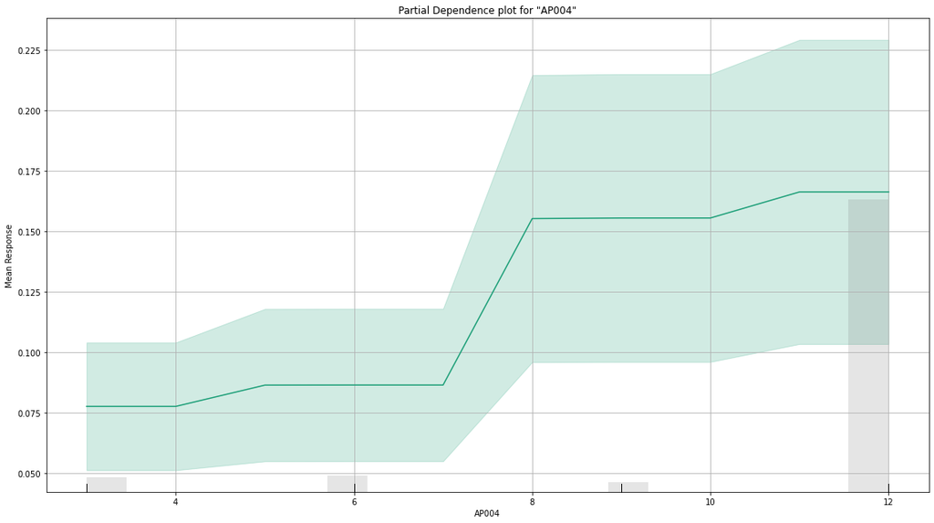

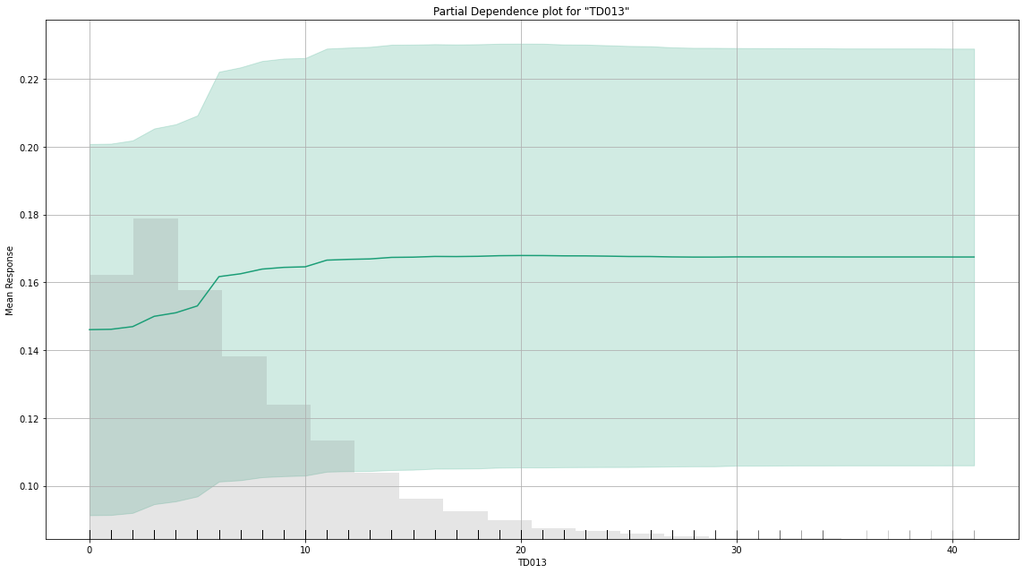

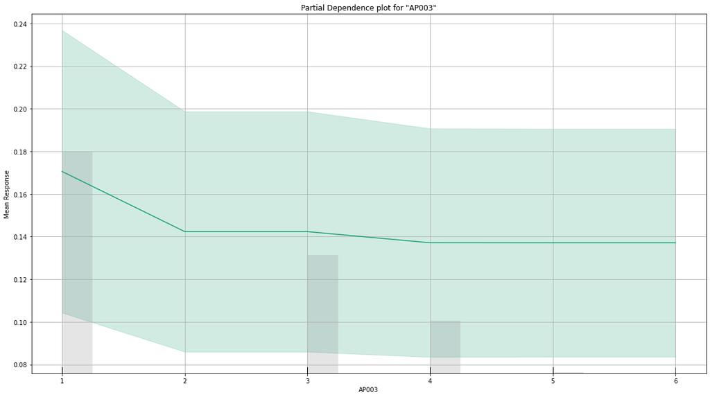

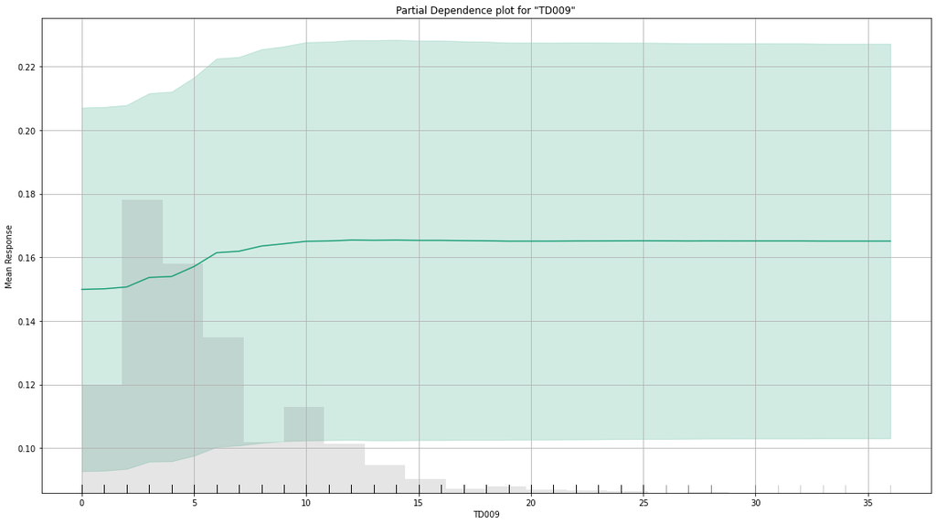

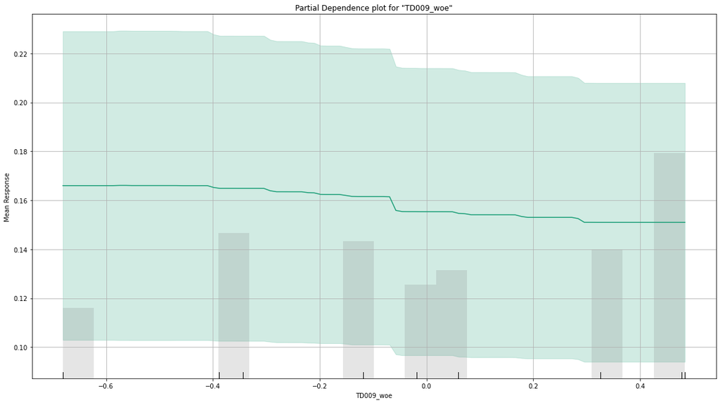

Individual Conditional Expectation

> An Individual Conditional Expectation (ICE) plot gives a graphical depiction of the marginal effect of a variable on the response. ICE plots are similar to partial dependence plots (PDP); PDP shows the average effect of a feature while ICE plot shows the effect for a single instance. This function will plot the effect for each decile. In contrast to the PDP, ICE plots can provide more insight, especially when there is stronger feature interaction.

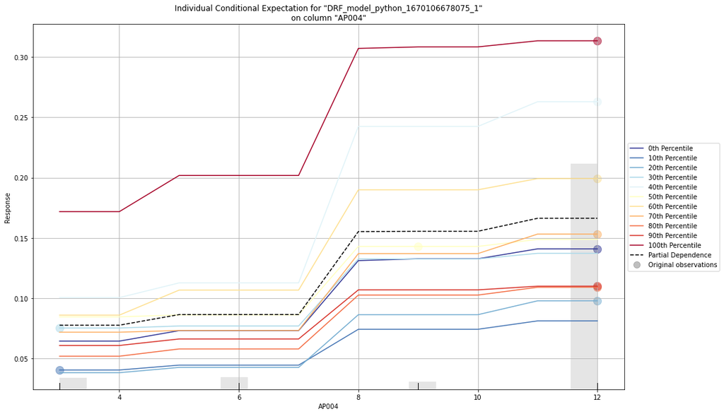

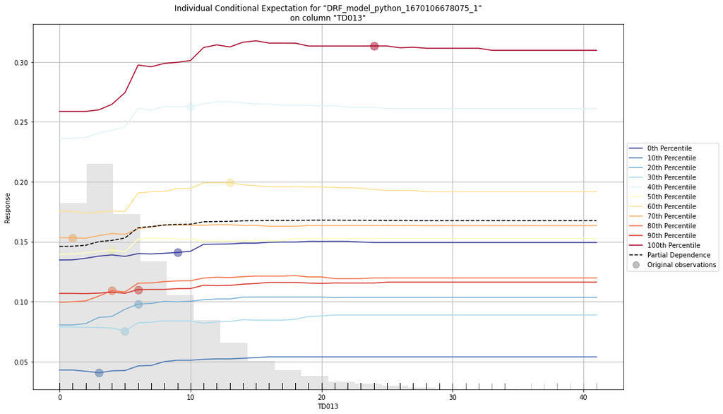

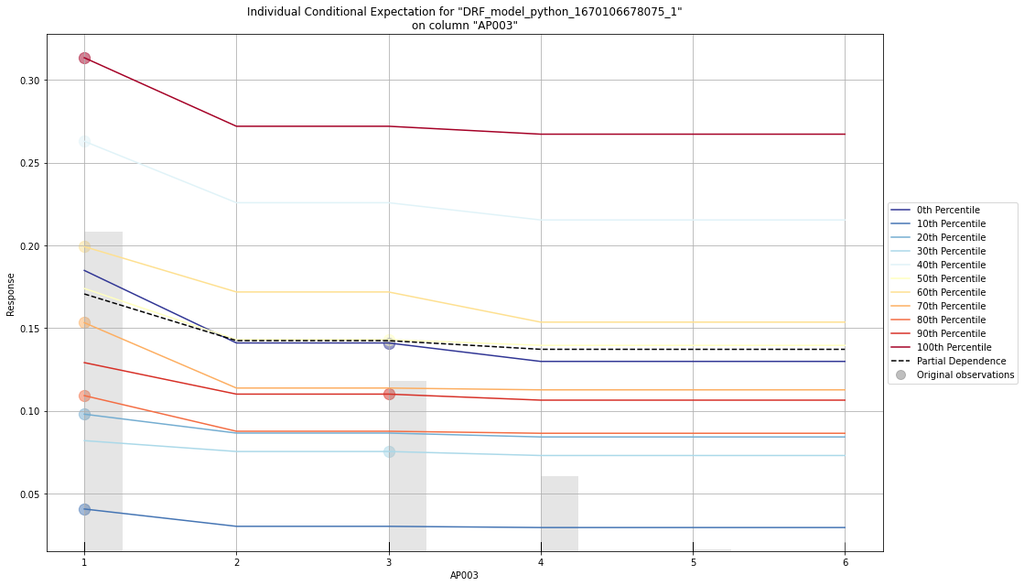

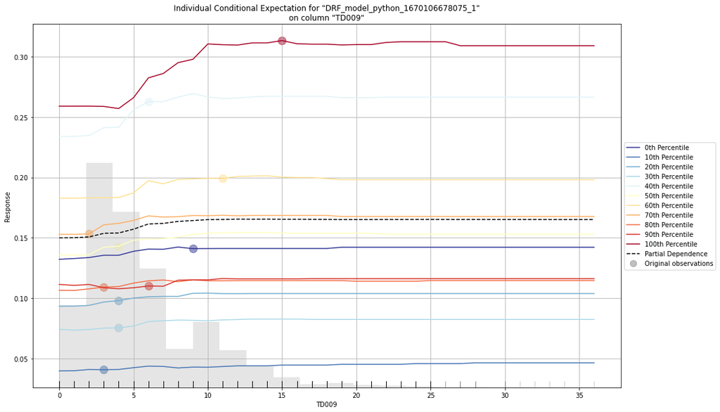

[1 more figures not shown]

```python
explainer = forest.explain(test)
```